# Ford BikeGo Explanatory Visualisation

## by Anita Obarakpor

Ford GoBike is a bike sharing system available in San Fransisco. Similar to other bike share systems, Ford GoBike consists of a fleet of bikes that can be unlocked in one station and returned in any other network station. Thus, this is ideal for one-way trips. These bikes are available for use thorughout the year and riders have access to all bikes in the network.

## Investigation Overview

In this investigation, I want to look at what factors contribute to a greater frequency of rides. The variables i will focus on are gender, user type, age and the time and date of rides.

## Dataset Overview

The dataset has 3023992 bike share trips that took place within the San Francisco Bay Area. The attributes recorded are

- bike id, start and end station id as strings
- start and end station latitude and longitudes as floats
- user status(subscriber or just a customer)
- gender of the user
- trip start time and duration
- income level of the trip
- the specific time in terms of date, hour, day of the week , month and year, the trips were taken
- estimated distance travelled on rides
- age group of riders

## User by Gender and Age Group

Checking the number of trips taken by both genders and the different age group, almost three-quarters of rides were taken by male compared to females. Approximately 73% of rides were taken by users between 20 and 40 years of age which means the rides are most popular among makes and young adults.

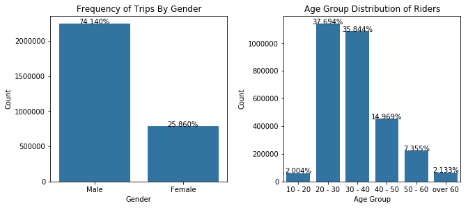

## Subscribed or Not?

Looking at the count of trips taken by both user types, it is easy to see that most rides (almost 90%) are taken by people with an active subscription

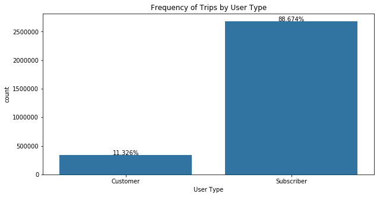

## Has the service grown over time?

Generally, there has been a upward trend in the number of rides taken since the inception in June of 2017 which means that the business has seen some growth.

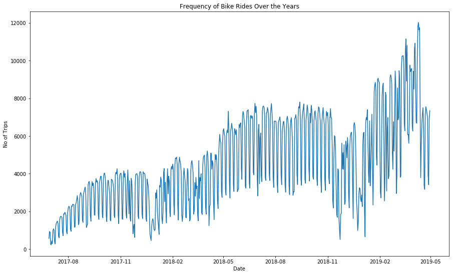

## When are the most popular times for rides?

Among, subscribers,the hours in which rides are most frequent correspond with those of a typical work/school commute (7-9am and 4-6pm) while for customers without a subscription rides are mostly popular on weekends for leisure.

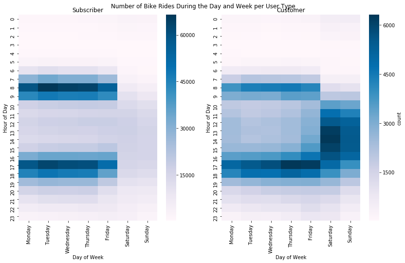

## Relationship Between Age/User Type and Trip Distance/Age

There is no linear correlation between age or and length of trips. However, there is a subtle parabolic curve that shows that riders between 20 and 40 years take the most and the longest trips in terms of distance. The regression shows that females and non_subscribed customers take slighlty longer trips on average than males and subscribers. This could mean that the average work/school commute is a relatively short trip.

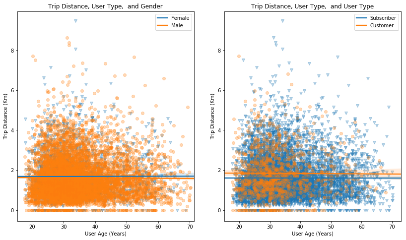